# Seattle Yelp Restaurants Rating Analysis

December 8, 2017

# Are there biases in Yelp ratings for restaurants in different socioeconomic statuses?

## Decision context maker

With our decision, what we are trying to inform the Office of Economic Development is to change how they decide to allocate their public fundings. With the information we have, we hope to be able to change allocations of their fundings to improve quality of life in underfunded communities. We chose to base our decision context around OED city officials in order to raise awareness on the issues of economic disparity among less funded community along different census tracts. With this, it will provide an opportunity for business owners to be more successful without the social impact of Yelp bias.

## Yelp Restaurants in Seattle

[figure not shown]

This map above the locations for all of the restaurants in the Seattle Area that we used for our project. In the future, we will be plotting each restaurant with a certain color that is determined based on their current rating. 1852 restaurants from 157 different category were evaluated and used for this project.

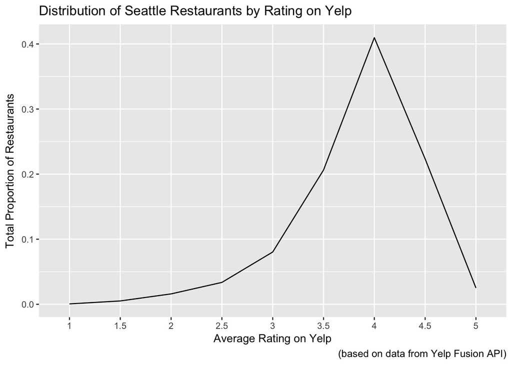

This graph is plotting the distribution of restaurants grouped by rating from 1 to 5 on a 0.5 scale. The x axis indicates the restaurant rating with 1 being the lowest and 5 being the highest. The y axis holds percentage in number of restaurants for each rating. The percentage for each rating level was calculated by dividing the frequency of restaurants with that rating by the sum of all restaurants in Seattle.

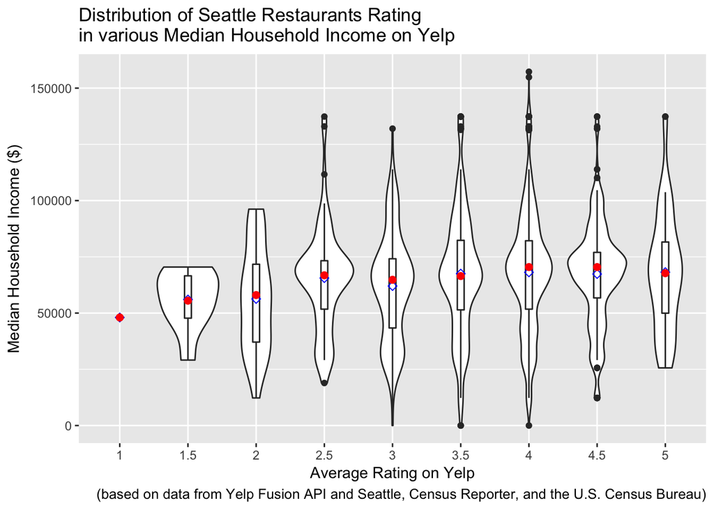

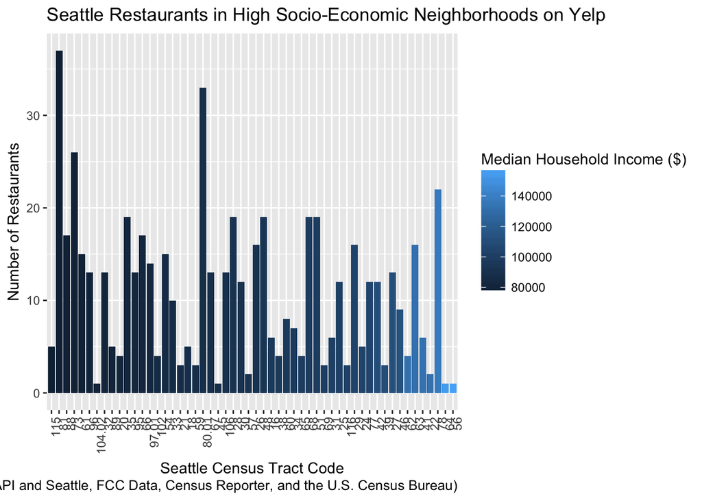

The data we had on the restaurants was broken down into three categories of high, mid and low SES based on median household income. It should be noted that it was not separated based on Seattle household income. The cut off for high socio-economic restaurants are the top 33% based on median household income, low socio-economic restaurants are the bottom 33%, and mid socio-economic restaurants are the cut off in between the high and low. This graph is plotting for the High SES which was determined to be a median household income of a minimum of $74,559 or more. This unique census tract holds 54 counts.

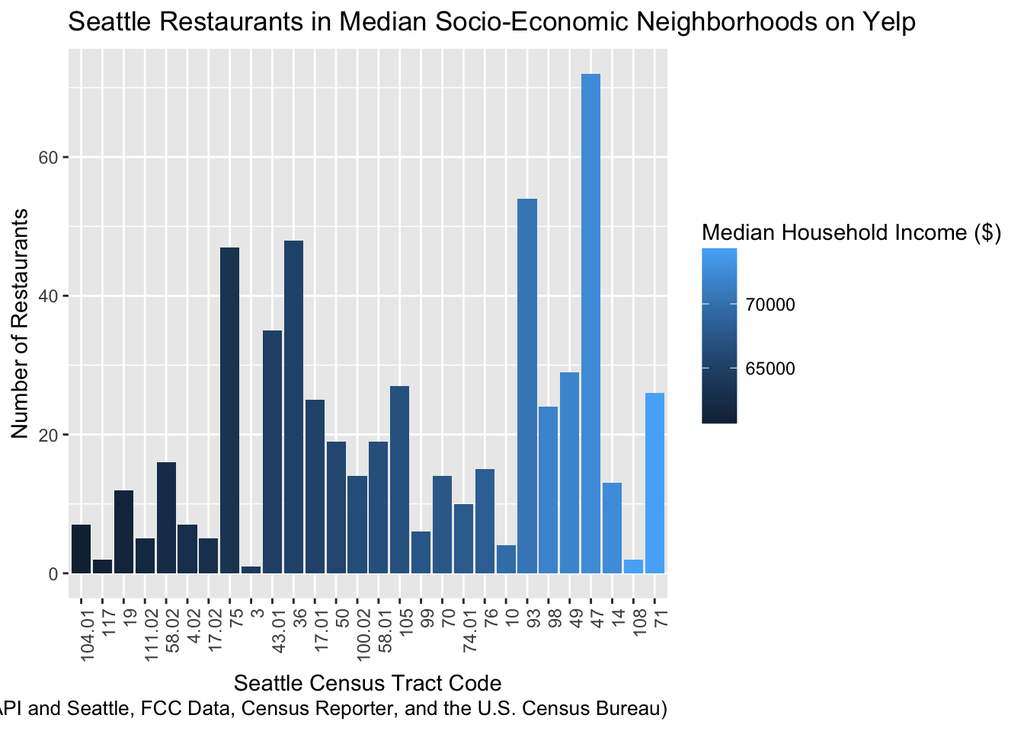

The restaurants in this data are within census tracts that have a median household income between $59,275 to $74,559. We have found there are 28 unique census tract. The x-axis are the unique census tracts in the dataset and the y-axis counts the number of restaurants in each census tracts. Out of the three socioeconomics, this bracket contains the least amount of census tract, which may imply there is less area that has restaurants spread out or there are not a lot of census tracts that falls within the middle socioeconomic status.

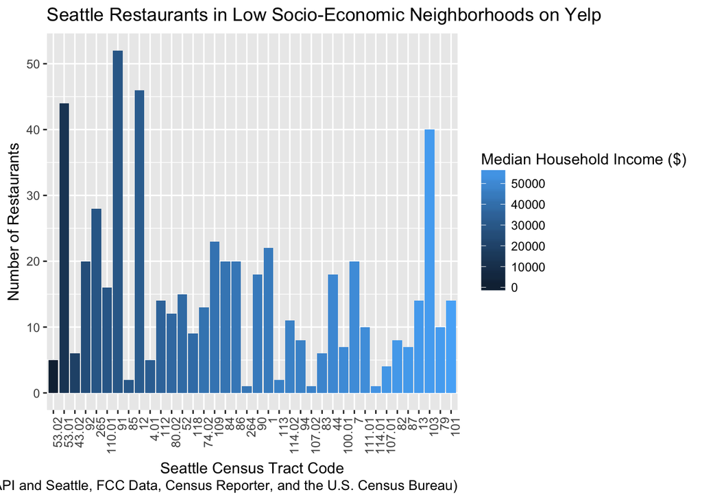

The restaurants in this data are within census tracts that have a low household income lower than $59,275. We have found there are 39 unique census tract. The x-axis are the unique census tracts in the dataset and the y-axis counts the number of restaurants in each census tracts. We see that there is a disproportionate spread in number of restaurants in each census tracts within the lower household income bracket. This can indicate a bigger, densely populated census tract or a more commercialized area to open restaurant business.

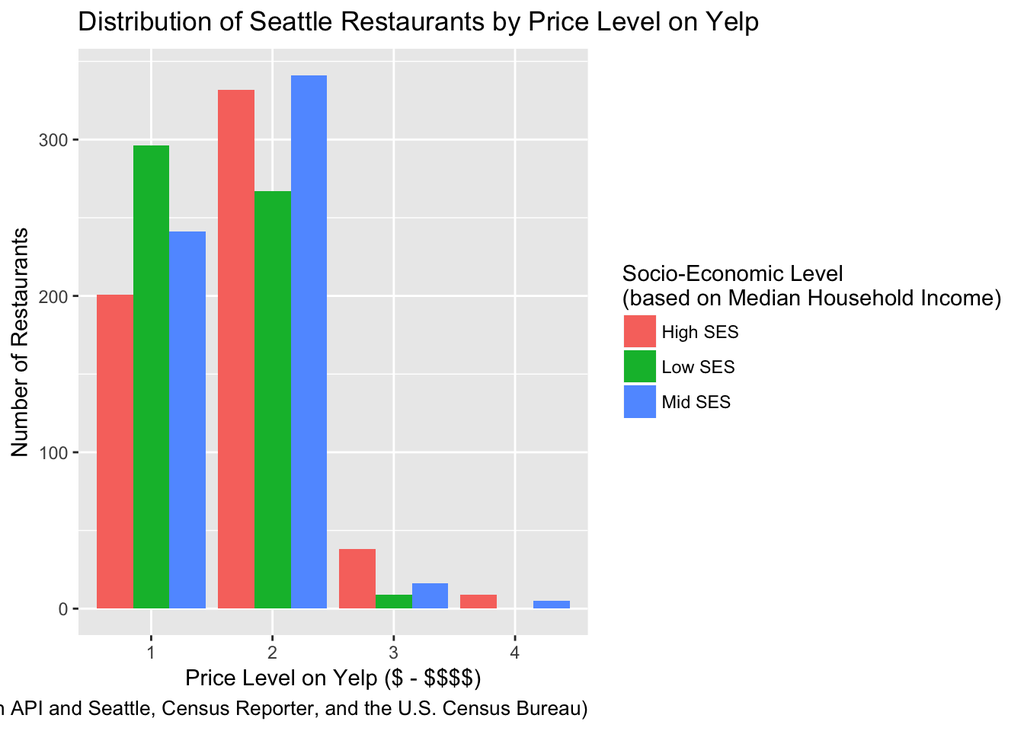

## Features

With our analysis, the dataset provides a multitude of features and factors relating to restaurants quality. Every Yelp restaurant in our dataset has the features below that we can analyze:

**Rating (*integer*)**: the restaurant’s average rating for given by Yelp community users

**reviewCount (*integer*)**: the restaurant’s total number of reviews given by Yelp community users

**recentHealthViolationType (*string*)**: the type of violation (red or blue) the restaurant had during the most recent restaurant inspection. Red refers to high risk factors that considered improper practices or procedures identified as the most prevalent contributing factors of foodborne illness or injury. Blue refers to low risk factors that are considered preventive measures to control the addition of pathogens, chemicals, and physical objects into foods.

**recentHealthInspectionScore (*integer*)**: the restaurants total points of violation given by King County food inspector during the most recent restaurant inspection. Inspection point is a cumulative violation point of red and blue violation type. Each violation within red high risk factors and blue low risk factors has an associated points. Health Inspection Score is the sum of violation points during a single restaurant inspection visit.

**totalInspectionScore (*integer*)**: the total sum of all historical health inspection score for the restaurant given by King County food inspector.

**totalInspectionCount (*integer*)**: the total count of inspection visit at the restaurant

**avgInspectionSore (*integer*)**: the overall average inspection score of the restaurant. Formula: totalInspectionScore / totalInspectionCount

**restaurantTotalMonths (*integer*)**: the estimated total months the restaurant has been opened. The number is calculated by the date difference between the most recent and earliest inspection date.

**restaurantMaxSeats (*integer*)**: the maximum number of seatings described by the King County food inspector.

**recentHealthInspectionResult (*string*)**: the inspection condition (Complete, Incomplete, Not Ready for Inspection, Unsatisfactory, or Satisfactory) given at the end of the most recent food inspection visit by a King County food inspector

**recentHealthInspectionGrade (*integer*)**: the restaurant food safety rating given by a King Country food inspector. (1 - Excellent, 2 - Good, 3 - Okay, 4 - Needs to Improve)

To further investigate Yelp restaurants rating in various socio-economic neighborhood, we trained a regression model using the features above. In our regression model, we looked to see what predictor variables (features) are important to the outcome variable (rating). Prior to training a regression model, we evaluated the above features to see which one has a strong correlation with restaurants rating.

recentHealthViolationType, recentHealthInspectionResult, and recentHealthInspectionGrade are categorical variables, which we converted into dummy variables for modeling.

## Features Ranked by Importance for Yelp Restaurants Rating in high Socio-economic area

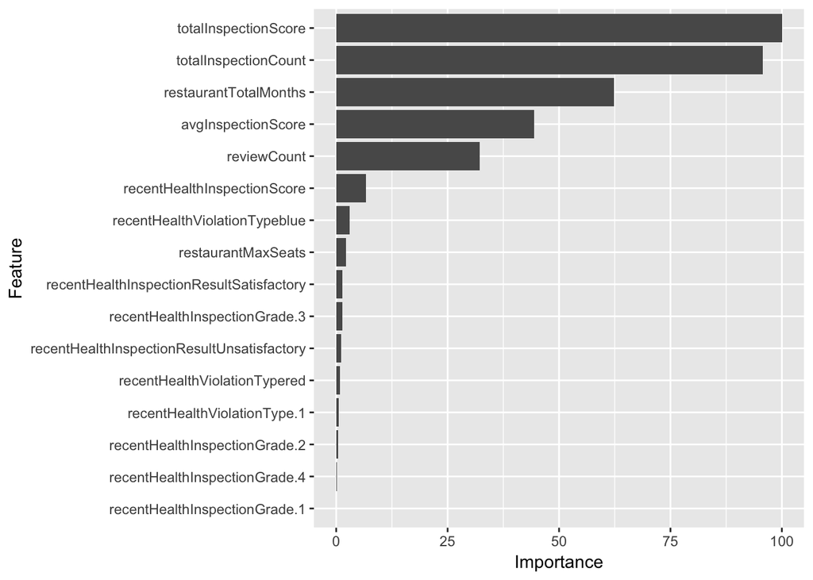

## Features Ranked by Importance for Yelp Restaurants Rating in low Socio-economic area

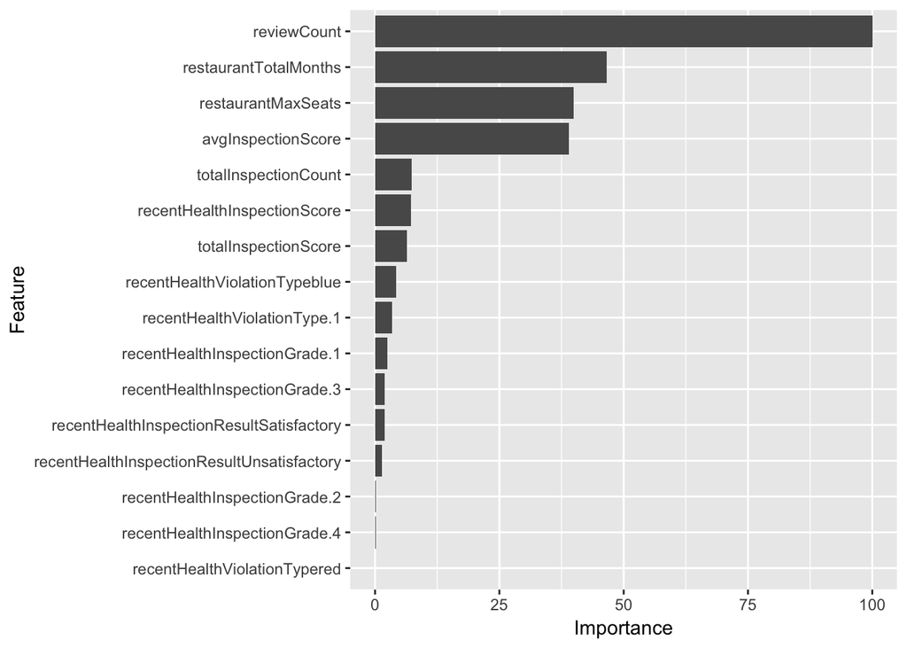

## SVM Regression Model for Yelp Restaurants

As a means to analyze Yelp restaurants rating, we trained two regression model: restaurants in high socio-economic and restaurants in low socio-economic neighborhood. For prediction in our model, however, we used the contrasting socio-economic data; meaning, inputting restaurants in low socio-economic restaurants for a high socio-economic model and vice versa. Next, we built a residual graph for each model. By looking at the residuals, we can evaluate how a set of restaurants would perform in various socio-economic regression model. If a majority of the residuals lie above the 0 line in a residual graph, the model suggested an underestimation for the predicted set of restaurants. If a majority of the residuals lies below the 0 line, the model suggested an overestimation for the predicted set of restaurants.

### High Socio-Economic Restaurants

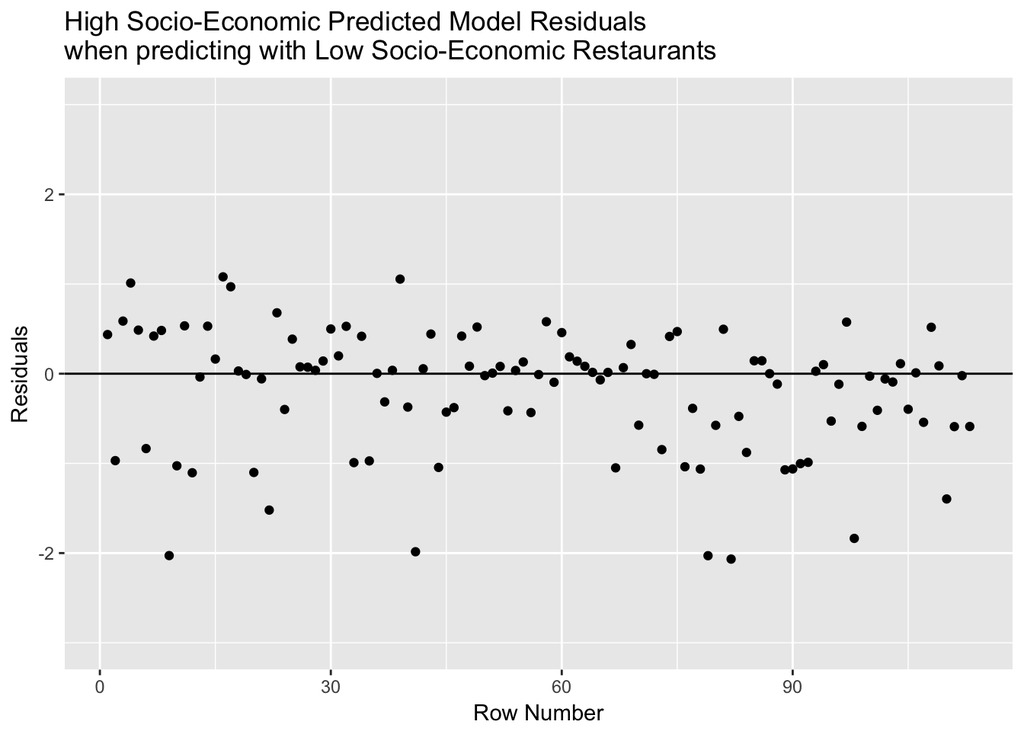

```
## Overestimated residuals proportion:  0.5044248
```

```
## Underestimated residuals proportion:  0.4955752
```

### Low Socio-Economic Restaurants

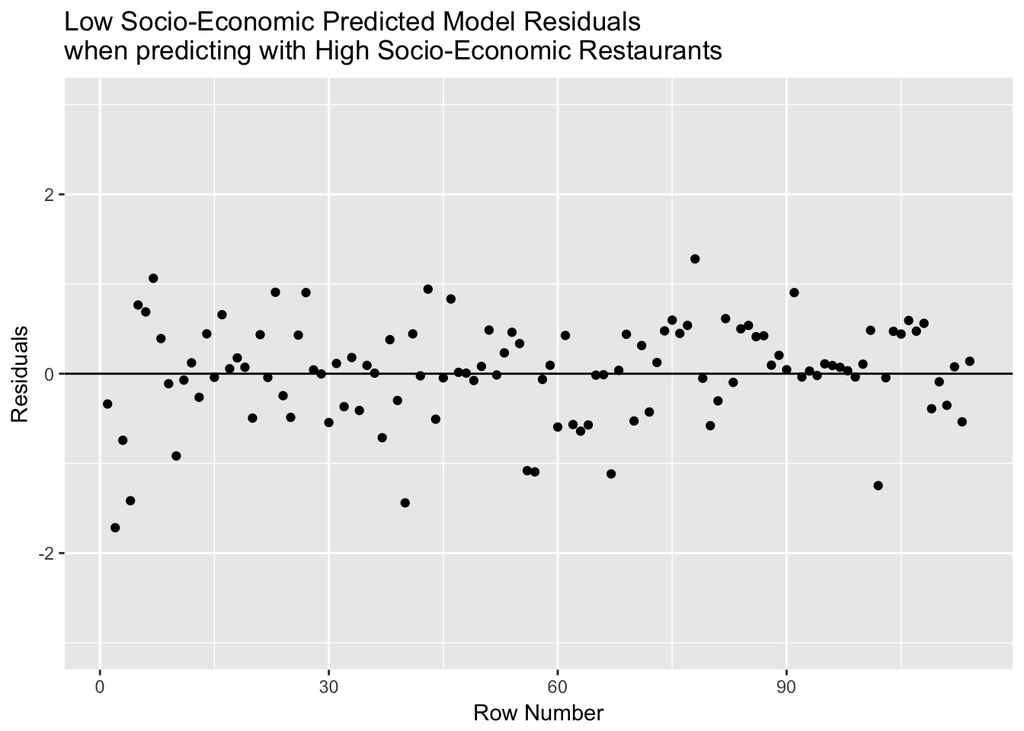

```
## Overestimated residuals proportion:  0.4385965
```

```
## Underestimated residuals proportion:  0.5614035
```

To further investigate the results, we ran the same regression models for Subway restaurants in high socio-economic and low socio-economic neighborhood and plot the residuals. Below is the results:

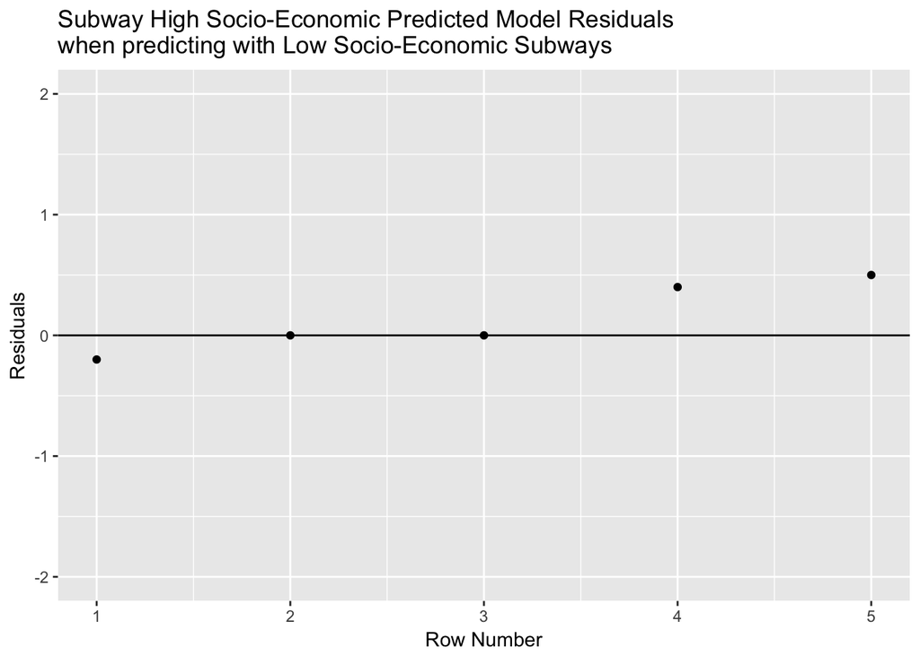

```
## Overestimated residuals proportion:  0.2
```

```
## Underestimated residuals proportion:  0.8
```

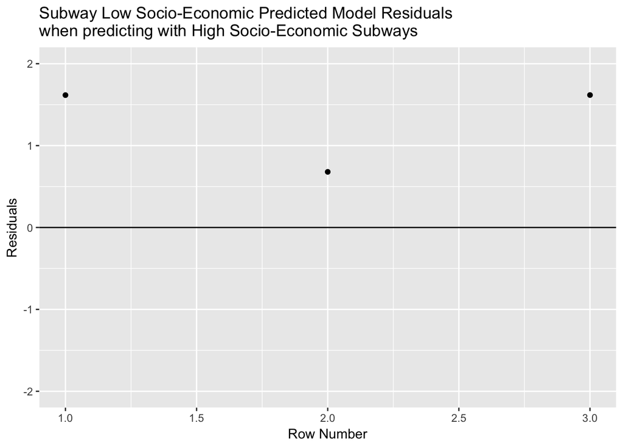

```
## Overestimated residuals proportion:  0
```

```
## Underestimated residuals proportion:  1
```

## Conclusion

The analysis may not provide a conclusive evidence that there is biased in restaurants rating based on socioeconomic status, however, it provides a foundation to future research on restaurants rating. There is an array of factors that contribute to a restaurant’s quality such as location proximately, food freshness, taste, and many more that we have not included in the analysis. In addition, there are also other information that we can pull from the City of Seattle such as crime rate/index in neighborhoods, median house rental price, number of individual household members, average age of a neighbourhood, and more. In future research, we hope to include those additional factors and features to enhance our regression model and findings.